# note11

### Stationary Process

`-` 마코프체인이 적당히 큰 시점 이후에 분포가 동일해지는 상황에 집중하여 보자. 즉 $X_t$의 분포가 $X_{t+1}$의 분포와 거의 비슷해지는 특이한 확률변수열에 대하여 집중하여 보자.

`-` 이해를 돕기 위하여 날씨예측예제를 다시 생각해보자.

*[날씨예측예제, remind]*

`-` 아래와 같이 세상의 법칙이 있다고 하자.

- 맑/맑: 0.4
- 맑/비: 0.3
- 비/맑: 0.2
- 비/비: 0.1

`-` 모든 $t$에 대하여 확률변수 $X_t$를 아래와 같이 정의하자.

- 맑: $X_t=0$
- 비: $X_t=1$

`-` 오늘 (2021년5월8일) 비가 왔다고 치자. 10000일 뒤에도 비가 올 확률은 얼마일까?

`-` 풀이 1,2,3,4가 있었는데 풀이 3,4가 특이했었다.

`-` 풀이 3,4에서는 특별한 가정을 사용해서 풀었는데, 그 특별한 가정은 "9999일 뒤에 비가 올 확률 = 10000일 뒤에 비가 올 확률" 이다.

`-` 이 특별한 가정은 우리 예제에서는 타당했는데, 그 타당성은 풀이2에서 확인할 수 있었다.

`-` 풀이2에서는 $X_t$가 주어졌을 경우 $X_{t+1}$의 조건부확률을 정리한 매트릭스 ${\bf P}$ (전이확률이라고도 함) 를 이용해서 10000일 뒤에 비가 올 확률을 정확하게 계산하는 방법을 고안하였다. (이러한 매트릭스 ${\bf P}$를 모순없이 정의할 수 있는 이유는 $\{X_t\}$가 마코프체인이기 때문.) 구체적인 풀이는 아래와 같았다.
$${\bf P}^{9999}\mu=\begin{bmatrix} 0.6086957 & 0.6086957 \\ 0.3913043 & 0.3913043 \end{bmatrix}\begin{bmatrix} 0 \\ 1 \end{bmatrix}=\begin{bmatrix} 0.6086957 \\ 0.3913043 \end{bmatrix}$$

`-` 이 수식에서 $\pi=\begin{bmatrix} 0.6086957 \\ 0.3913043 \end{bmatrix}$라고 두고 식을 다시쓰면

$${\bf P}^{9999}\mu=\pi \quad \cdots (\ast)$$

`–` 풀이2중 독특한 관찰을 했던것이 기억나는데 적당히 큰 수 $M$ 이후에는 ${\bf P}^{M}={\bf P}^{M+1}={\bf P}^{M+2}=\dots={\bf P}^{\infty}$ 이 성립하였음을 관찰할 수 있었다.

- 편의상 ${\bf P}^{9997}={\bf P}^{9998}={\bf P}^{9999}={\bf P}^{10000}=\dots={\bf P}^{\infty}$ 로 생각할 수 있다는것을 의미

`-` 수식 $(\ast)$이 상당히 미묘하다.

`(1)` $\pi$는 $X_{10000}$의 확률질량함수를 의미함.

- 구체적으로 $X_{10000}$의 확률질량함수는 아래와 같이 쓸 수 있다.

| $x$ | $0(={\tt 맑음})$ | $1(={\tt 비옴})$ |
| --- | --- | --- |
| $p(x)$ | $0.6087$ | $0.3913$ |

`(2)` $(\ast)$의 좌변에 $\mu$에 아무값이나 넣어도 (각 원소를 더해서 1이기만 하면) 우변의 값은 항상 동일하다.

- 이것은 5월8일 날씨에 상관없이 항상 10000일 뒤에 비가 올 확률은 동일하다는 것을 의미한다.

`(3)` $(\ast)$를 관찰해보니 좌변의 9999대신에 9998을 넣어도 상관없을것 같다. 심지어 10000을 넣어도 상관없을것 같다.

- 특정한 시점 $M$ 이후에 $X_t$들의 분포가 모두 동일하다.

`-` (1)-(3)의 관찰들을 종합하면 아래와 같다.

> 마코프체인 $X_t$와 그것에 대응하는 전이확률 매트릭스 (transition matrix) ${\bf P}$가 주어졌다고 하자. ${\bf P}$가 적당한 성질을 만족한다면 마코프체인 $X_t$는 (초기조건이 어떻든 관계없이) 특정 시점 이후에 항상 동일한 확률분포 $\pi$를 가진다.

`-` 적당한 조건이 어떤것이 있을까? 우선 생각나는것은 아래와 같다.

`-` 성질1: 매트릭스 ${\bf P}$를 거듭제곱할수록 점점 어떠한 매트릭스 ${\bf P}^{\infty}$에 가까워진다.

`-` 성질2: ${\bf P}^{\infty}$ 각 row의 원소들은 모두 동일한 값을 가진다.

`-` 이러한 성질을 압축한것이 바로 아래의 조건이다.

> ${\bf P}^{\infty}$의 거듭제곱은 항상 어떠한 매트릭스 ${\bf P}^{\infty}$로 수렴하고, ${\bf P}^{\infty}$는 (각 원소의 합이 1인) 임의의 $\mu$에 대하여 ${\bf P}^{\infty}\mu=\pi$를 만족한다.

`-` 아쉬움: 그런데 이를 확인하기 위해서는 매번 ${\bf P}$를 곱해보면서 ${\bf P}^{\infty}$를 만들어 봐야한다. 혹시 ${\bf P}$만 가지고 알 수 있는 방법은 없을까?

`-` 해결책: 아래식

$${\bf P}^{\infty}\mu=\pi$$

을 살짝 변형하면

$${\bf P}\big({\bf P}^{\infty}\mu\big)=\pi$$

와 같이 된다.

`-` 그런데 ${\bf P}^{\infty}\mu=\pi$ 이므로

$${\bf P}\pi=\pi \quad \cdots(\star)$$

가 된다.

`-` 따라서

> 마코프체인 $X_t$와 그것에 대응하는 전이확률 매트릭스 (transition matrix) ${\bf P}$가 주어졌다고 하자. 어떤 적당한 분포 $\pi$를 "어떤방식으로든" 찾아내서 $(\star)$가 성립함을 보인다면 (즉 ${\bf P}\pi=\pi$ 임을 보인다면) 마코프체인 $X_t$는 (초기조건이 어떻든 관계없이) 특정 시점 이후에 항상 동일한 확률분포를 가지며 그 분포가 $\pi$라고 주장할 수 있다.

`-` 이때 $\star$를 만족하는 $\pi$를 $X_t$의 정상분포 (stationary distribution) 라고 한다.

#### $(\star)$의 다른 표현

`-` 날씨예제의 경우

$${\bf P}=\begin{bmatrix} P(X_{t+1}=0|X_{t}=0) & P(X_{t+1}=0|X_{t}=1)\\ P(X_{t+1}=1|X_{t}=0) & P(X_{t+1}=1|X_{t}=1) \end{bmatrix} \quad \pi=\begin{bmatrix}P(X_{\infty}=0) \\ P(X_{\infty}=1) \end{bmatrix}$$

`–` 편의상 아래와 같이 기호를 약속하자.

$${\bf P}=\begin{bmatrix} p(0,0) & p(1,0)\\ p(0,1) & p(1,1) \end{bmatrix} \quad \pi=\begin{bmatrix}\pi(0) \\ \pi(1) \end{bmatrix}$$

`-` $\pi={\bf P}\pi $를 풀면

$$\pi(0)=p(0,0)\pi(0)+p(1,0)\pi(1)$$$$\pi(1)=p(0,1)\pi(0)+p(1,1)\pi(1)$$

`-` 따라서 조건 $\pi=P\pi$가 만족한다는 것은 모든 $y=0,1$에 대하여 아래식이 성립한다는 조건과 같다.

$$\pi(y)=\sum_x p(x,y)\pi(x) \quad \cdots (\star)$$

`–` 날씨예제에서는 $x,y$의 값이 0 또는 1이었지만 좀더 일반적인 경우에서도 위의 논의가 성립한다.

### Detailed balance condition

`–` 어떠한 마코프체인 $X_t$가 있다고 하자. 그리고 모든 $x,y$에 대하여 전이확률을 $p(x,y)$라고 하자. 어떤 $\pi(y)$가 모든 $x,y$에 대하여 아래를 만족한다고 하자.

$$\pi(y)p(y,x)=\pi(x)p(x,y) \quad \cdots (\star\star)$$

`–` 이 조건을 detailed balance condition이라고 한다.

`-` detailed balance condition의 양변에 $\sum_x$를 취하면

$LHS=\pi(y)\sum_x p(y,x)=\pi(y)\sum_xP(X_{t+1}=x | X_t =y)=\pi(y)$

$RHS=\sum_x \pi(x)p(x,y)$

가 되어서 조건 $(\star)$가 성립한다. 따라서 조건 $(\star\star)$가 성립하면 조건 $(\star)$가 성립된다.

`-` 그렇다면 아래의 정리가 성립한다.

> 마코프체인 $X_t$와 그것에 대응하는 전이확률 매트릭스 (transition matrix) ${\bf P}$가 주어졌다고 하자. 어떤 적당한 분포 $\pi$를 "어떤방식으로든" 찾아내서 $(\star\star)$가 성립함을 보인다면 (즉 detailed balance condition 이 만족함을 보인다면) 마코프체인 $X_t$는 (초기조건이 어떻든 관계없이) 특정 시점 이후에 항상 동일한 확률분포를 가지며 그 분포가 $\pi$라고 주장할 수 있다.

`-` $X_t$가 가지는 정상분포 $\pi(x)$를 $f(x)$라고 쓰고 $y=x_{t+1}$, $x=x_{t}$를 대입하면 $(\star\star)$를 아래와 같이 쓸 수도 있다.

$$f(x_{t+1})P(x_t|x_{t+1})=f(x_t)P(x_{t+1}|x_t)$$

`-` 의문1: 어지간한 마코프체인 $\{X_t\}$는 모두 ${\bf P}^{\infty}$이 존재하지 않나?

- 아니다. ${\bf P}=\begin{bmatrix} 0 & 1 \\ 1 & 0 \end{bmatrix}$를 상상하자. ${\bf P}^2={\bf I}$, ${\bf P}^3={\bf P}, \dots$

`–` 의문2: 그냥 $X_t$가 iid열이 아니라 동일한 분포를 가지는 열이라고 가정하면 안되나?

- 안된다. stationary process는 동일한 분포를 가지는 확률변수열보다 훨씬 더 유용하다. 간단한 예로 $X_1$은 0.5의 확률로 0 또는 1의 값을 가지고 $X_1=X_2=X_3=X_4=\dots$ 라고 하자. 분명히 $X_1=X_2=\dots$는 같은 분포를 가진다. 하지만 하나의 앙상블에서 관측한 열은 항상 1 혹은 항상 0이다. (비가 오면 그 다음날에도 비가 오고, 비가 오지 않으면 계속 비가 오지 않음) 이러한 경우는 10000일의 시점에서 앙상블평균은 1/2이지만 시간평균은 0 혹은 1이다.

### 메트로폴리스-헤이스팅스

### 예제1

다시 $B(2.7,6.3)$를 추출하는 예제로 돌아오자.

#### 시도1

`-` 우선 우리가 관심이 있는 타겟분포를 그려보자.

```r
f<-function(x){
    alpha=2.7
    beta=6.3
    gamma(alpha+beta)/gamma(alpha)/gamma(beta) * x^(alpha-1)*(1-x)^(beta-1)
}
```

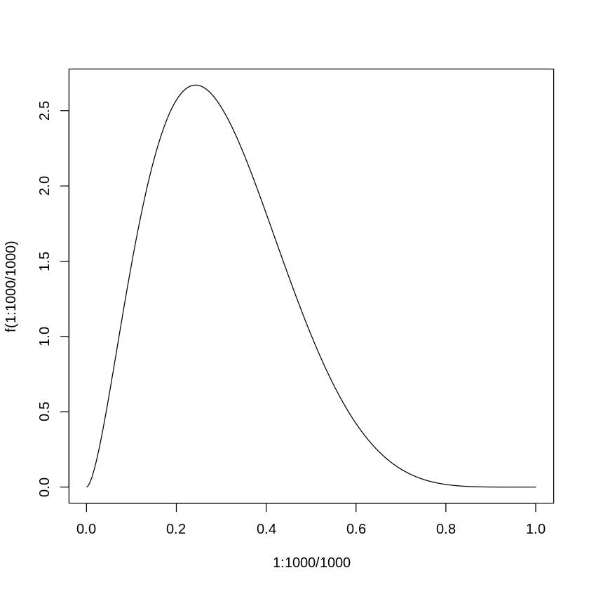

```r
plot(1:1000/1000,f(1:1000/1000),type='l')
```

```r
X<-rep(0.1,5000)
```

```r
print(head(X))
```

```
[1] 0.1 0.1 0.1 0.1 0.1 0.1
```

`-` 현재 $X$의 값은 모두 0.1이다. 그런데 궁극적으로는 $X$의 값을 모두 $Beta(2.7,6.3)$에서 생성된 샘플들로 채우고 싶다.

```r
set.seed(1)
Y<-runif(1)
print(Y)
```

```
[1] 0.2655087
```

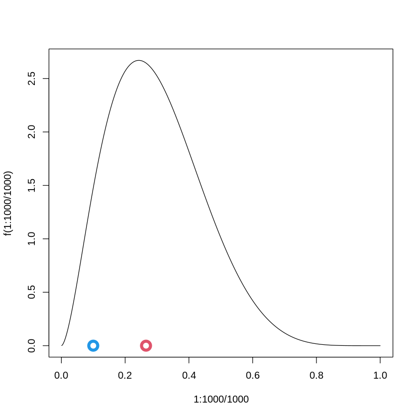

```r
plot(1:1000/1000,f(1:1000/1000),type='l')
points(Y,0,col=2,cex=2,lwd=5)
points(X[1],0,col=4,cex=2,lwd=5)
```

`–` 빨간점이 $Y$이고 파란점은 $X$이다. 두개의 점중에서 어떤것이 $f(x)$에서 생성되었다고 믿어지는 점일까?

`-` 빨간색 점이 더 가능성이 높아보인다. (pdf값이 더 높음)

`-` $X[2]$의 값은 그냥 빨강으로 결정하자.

```r
X[2]<-Y
```

```r
print(head(X))
```

```
[1] 0.1000000 0.2655087 0.1000000 0.1000000 0.1000000 0.1000000
```

`-` 다시 $Y$를 하나 뽑자.

```r
set.seed(2)
Y<-runif(1)
print(Y)
```

```
[1] 0.1848823
```

`-` 다시 뽑은 $Y$는 초록색으로 표현하자.

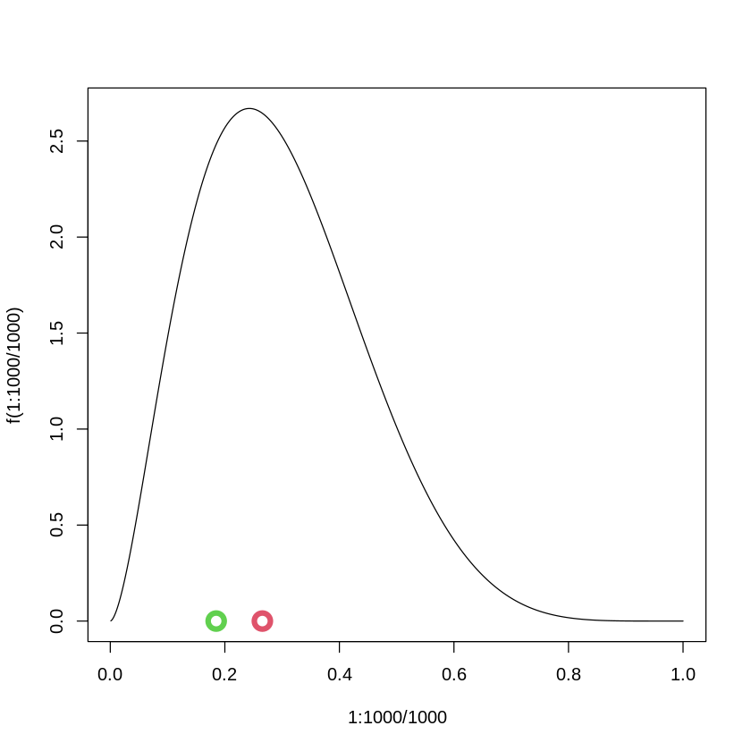

```r
plot(1:1000/1000,f(1:1000/1000),type='l')
points(Y,0,col=3,cex=2,lwd=5)
points(X[2],0,col=2,cex=2,lwd=5)
```

`–` 둘중에 어떤것이 더 $Beta(2.7,6.3)$에서 추출한 샘플 같은가?

`-` 여전히 빨강이 더 $Beta(2.7,6.3)$의 분포에서 나온것 같다.

`-` 그러면 $X[3]$의 값도 그냥 빨강으로 한다.

`-` 지금까지의 결과를 요약하면 아래와 같다.

| $t$ | $X_t$ | $Y_t$ | 설명 |
| --- | --- | --- | --- |
| $1$ | $0.1$ | $0.2655087$ | $Y_1$이 $X_1$보다 더 $Beta(2.7,6.3)$에서 나온 분포같았음 $\to$ $X_2$는 $Y_1$로 선택 |
| $2$ | $0.2655087$ | $0.1848823$ | 이번에는 $X_2$가 $Y_2$보다 더 $Beta(2.7,6.3)$에서 나온 분포같음 $\to$ $X_3$는 $X_2$로 선택 |
| $3$ | $0.2655087$ | $-$ | - |
| $\dots$ | $\dots$ | $\dots$ | $\dots$ |

`–` 이걸 무한대로 반복하면 $X_t$는 결국 $Beta(2.7,6.3)$에서 뽑혔을법한 샘플들로 점점 채워진다.

`-` 따라서 $\{X_1,X_2,X_3,\dots,X_{5000}\}$을 모아서 히스토그램을 그리면 적당히 $Beta(2.7,6.3)$에서 추출한 표본이라 주장할 수 있을것 같다.

`-` 앞부분은 내가 임의로 값을 주는것에 따라 다르니까 대충 앞에 100개정도는 버리고 $\{X_{101},X_{102},\dots,X_{5000}\}$를 모아서 히스토그램을 그리면 좀 더 좋은 그림이 나올것 같다.

#### 시도2

`-` 시도1의 당연한 우려점은 특정시점 이후에는 $X_t$는 거의 하나의 값만 나올것 같다는 것이다.

`-` 즉 우연히 $X_t$가 pdf의 최고점에서 찍힌다면, 그 이후에는 거의 $X_t$는 하나의 값만 나올것

`-` 당장 위의 예제만 살펴봐도 $X_4, X_5,X_6,\dots$ 뽑아보았자 당분간은 $X_4=X_5=X_6=..=0.2655087$ 일것 같다.

`-` 히스토그램을 그려봤자 다 $0.2655087$에만 값이 몰려있을 것이다.

`-` 더 그럴듯한 샘플을 선택하는 아이디어는 좋은데, 그런식으로 진행하면 결국 반복할수록 pdf의 최고점을 향해 달려가는 꼴밖에 안된다.

`-` 다시 아래의 그림을 관찰해보자.

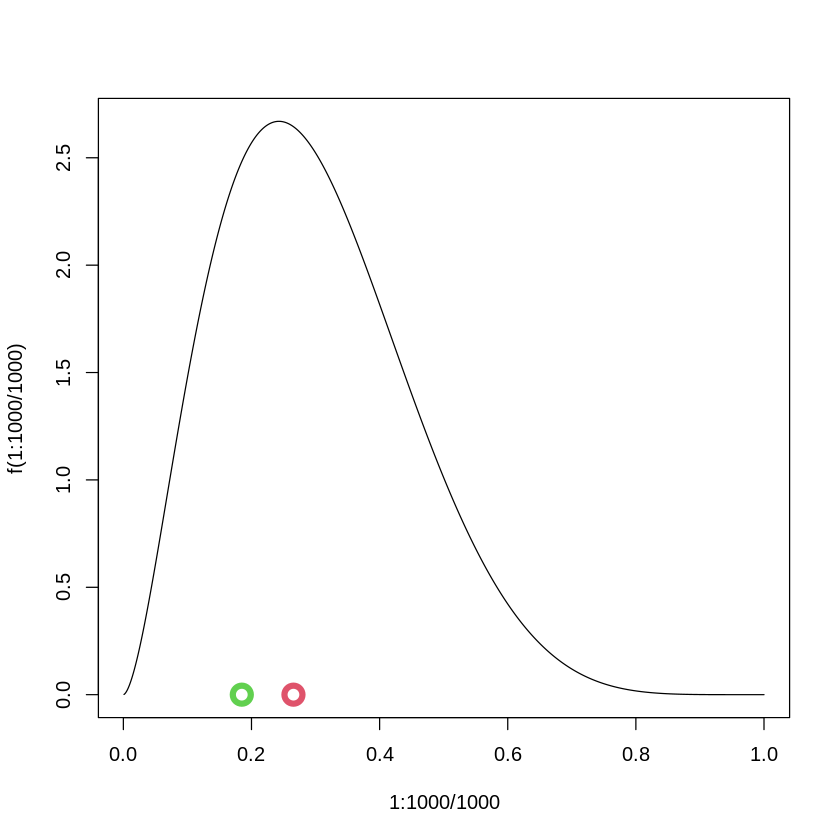

```r
plot(1:1000/1000,f(1:1000/1000),type='l')
points(Y,0,col=3,cex=2,lwd=5)
points(X[2],0,col=2,cex=2,lwd=5)
```

`-` 초록색점보다 빨간색 점이 더 pdf값이 높으므로 빨간색점이 더 $Beta(2.7,6.3)$에서 나왔음직한 샘플인것은 맞다.

`-` 그런데 $100\%$ 확신할 수 있는가?

`-` 빨간색점 0.2655087 에서의 pdf값은 아래와 같다.

```r
f(0.2655087)
```

2.64480579727479

`–` 반면 초록색점 0.1848823 에서의 pdf값은 아래와 같다.

```r
f(0.1848823)
```

2.48267809218198

`–` 사실 초록색점도 가능성 있는 점이다. 만약에 어떤사람이 $Beta(2.7,6.3)$에서 하나의 확률변수를 생성하고 나머지는 $U[0,1]$에서 생성했다고 치자. 두 결과를 초록색과 빨간색으로 표시되었다고 할때 어떤색이 $Beta(2.7,6.3)$에서 생성되었냐고 묻는다면 당신은 빨간색을 고를 것이다.

`-` 하지만 빨간색에 전재산을 베팅할 수 있는가?

```r
f(0.2655087) / (f(0.2655087)+f(0.1848823))
```

0.515809674743804

`-` 빨간색에 $51.58\%$의 재산만 베팅한다.

`-` 즉 빨간색이 $Beta(2.7,6.3)$에서 왔다고 믿을 확률이 $51.58\%$정도라는 의미이다.

`-` 제안하는 알고리즘

(1) $X_1$에 아무값이나 넣는다.

(2) 균등분포에서 $Y_1$을 뽑는다.

(3) $\frac{f(Y_1)}{f(X_1)+f(Y_1)}$의 확률로 $X_2=Y_1$을 선택하고 $\frac{f(X_1)}{f(X_1)+f(Y_1)}$의 확률로 $X_2=X_1$을 선택한다.

(4) (2)-(3)를 반복한다.

`-` 실행

```r
X<-rep(0.1,5000)
for (i in 2:5000){
    Y<-runif(1)
    acceptance_prob<-f(Y)/(f(X[i])+f(Y))
    U_<-runif(1)
    X[i]<- Y* (U_< acceptance_prob) +X[i-1] * (U_> acceptance_prob)
}
```

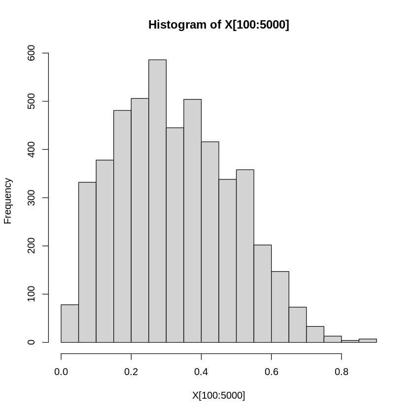

```r
hist(X[100:5000])
```

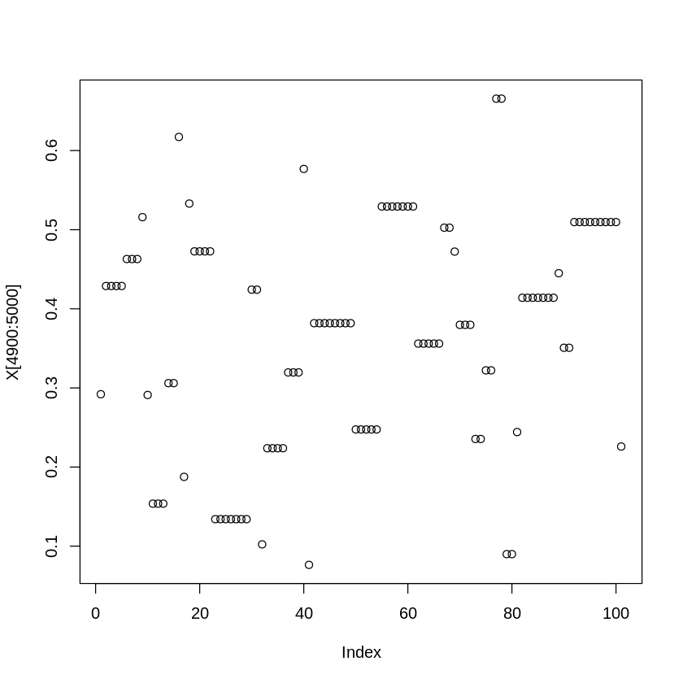

```r
plot(X[4900:5000])
```

`-` 이 알고리즘이 왜 성립하는가?

`-` 그러고 보니까 이 느낌을 어디서 받았다. (에르고딕, 정상성)

#### 시도2의 이론적 근거

`-` 주장: $X_{4999}$의 확률밀도함수와 $X_{5000}$의 확률밀도함수는 (독립은 아니지만) 서로 같고, 그 pdf는 $Beta(2.7,6.3)$을 따르는 확률변수의 pdf이다.

`-` $X_t$는 정상분포를 가지고 그 확률밀도함수가 $f(x)$임을 보이면 된다.

`-` 분포 $f$가 아래의 조건(detailed balance condition)을 만족시키는지를 확인하면 된다.

$$f(x_{t+1})P(x_t|x_{t+1})=f(x_t)P(x_{t+1}|x_t) \quad \cdots (\star\star)$$

`–` $x_{t+1}=x_t$ 이면 그냥 성립한다.

`-` $x_{t+1}\neq x_t$ 일 때 성립하는지 봐야한다. ($x_{t+1}=y_t$)

`–` $P(x_{t+1}|x_{t})=\frac{f(x_{t+1})}{f(x_t)+f(x_{t+1})}$

`–`$x_t$와 $x_{t+1}$의 순서를 바꾸면 $P(x_t|x_{t+1})=\frac{f(x_t)}{f(x_{t})+f(x_{t+1})}$

`–` $P(x_{t+1}|x_t)$와 $P(x_t|x_{t+1})$를 detailed balance condition $(\star\star)$에 대입하면 등호가 성립함을 쉽게 확인할 수 있다.